[figure not shown]

# [$$IBM HR Analytics Employee Attrition & Performance$$](https://www.kaggle.com/pavansubhasht/ibm-hr-analytics-attrition-dataset)

**Team members:**

1. [Kinga Klejne](https://github.com/KingaKlejne)
2. [Katarzyna Hewelt](https://github.com/kasiahewelt)
3. [Karolina Mastalerz](https://github.com/karolinamst)
4. [Piotr Nowicki](https://github.com/piotrnowicki1510)
5. [Dariusz Starosta](https://github.com/darstar-ds)

### Analysis: Why do People Resign?

[output not shown]

```python
import pandas as pd
import matplotlib.pyplot as plt
import numpy as np
import seaborn as sns
```

```python
df = pd.read_csv("WA_Fn-UseC_-HR-Employee-Attrition.csv")

df
```

|  | Age | Attrition | BusinessTravel | DailyRate | Department | DistanceFromHome | Education | EducationField | EmployeeCount | EmployeeNumber | ... | RelationshipSatisfaction | StandardHours | StockOptionLevel | TotalWorkingYears | TrainingTimesLastYear | WorkLifeBalance | YearsAtCompany | YearsInCurrentRole | YearsSinceLastPromotion | YearsWithCurrManager |
| --- | --- | --- | --- | --- | --- | --- | --- | --- | --- | --- | --- | --- | --- | --- | --- | --- | --- | --- | --- | --- | --- |
| 0 | 41 | Yes | Travel_Rarely | 1102 | Sales | 1 | 2 | Life Sciences | 1 | 1 | ... | 1 | 80 | 0 | 8 | 0 | 1 | 6 | 4 | 0 | 5 |
| 1 | 49 | No | Travel_Frequently | 279 | Research & Development | 8 | 1 | Life Sciences | 1 | 2 | ... | 4 | 80 | 1 | 10 | 3 | 3 | 10 | 7 | 1 | 7 |
| 2 | 37 | Yes | Travel_Rarely | 1373 | Research & Development | 2 | 2 | Other | 1 | 4 | ... | 2 | 80 | 0 | 7 | 3 | 3 | 0 | 0 | 0 | 0 |
| 3 | 33 | No | Travel_Frequently | 1392 | Research & Development | 3 | 4 | Life Sciences | 1 | 5 | ... | 3 | 80 | 0 | 8 | 3 | 3 | 8 | 7 | 3 | 0 |
| 4 | 27 | No | Travel_Rarely | 591 | Research & Development | 2 | 1 | Medical | 1 | 7 | ... | 4 | 80 | 1 | 6 | 3 | 3 | 2 | 2 | 2 | 2 |
| ... | ... | ... | ... | ... | ... | ... | ... | ... | ... | ... | ... | ... | ... | ... | ... | ... | ... | ... | ... | ... | ... |
| 1465 | 36 | No | Travel_Frequently | 884 | Research & Development | 23 | 2 | Medical | 1 | 2061 | ... | 3 | 80 | 1 | 17 | 3 | 3 | 5 | 2 | 0 | 3 |
| 1466 | 39 | No | Travel_Rarely | 613 | Research & Development | 6 | 1 | Medical | 1 | 2062 | ... | 1 | 80 | 1 | 9 | 5 | 3 | 7 | 7 | 1 | 7 |
| 1467 | 27 | No | Travel_Rarely | 155 | Research & Development | 4 | 3 | Life Sciences | 1 | 2064 | ... | 2 | 80 | 1 | 6 | 0 | 3 | 6 | 2 | 0 | 3 |
| 1468 | 49 | No | Travel_Frequently | 1023 | Sales | 2 | 3 | Medical | 1 | 2065 | ... | 4 | 80 | 0 | 17 | 3 | 2 | 9 | 6 | 0 | 8 |
| 1469 | 34 | No | Travel_Rarely | 628 | Research & Development | 8 | 3 | Medical | 1 | 2068 | ... | 1 | 80 | 0 | 6 | 3 | 4 | 4 | 3 | 1 | 2 |

1470 rows × 35 columns

[figure not shown]

### Attrition Breakdown

```python
df_no = df.loc[df['Attrition']== "No"]
df_no
```

|  | Age | Attrition | BusinessTravel | DailyRate | Department | DistanceFromHome | Education | EducationField | EmployeeCount | EmployeeNumber | ... | RelationshipSatisfaction | StandardHours | StockOptionLevel | TotalWorkingYears | TrainingTimesLastYear | WorkLifeBalance | YearsAtCompany | YearsInCurrentRole | YearsSinceLastPromotion | YearsWithCurrManager |
| --- | --- | --- | --- | --- | --- | --- | --- | --- | --- | --- | --- | --- | --- | --- | --- | --- | --- | --- | --- | --- | --- |
| 1 | 49 | No | Travel_Frequently | 279 | Research & Development | 8 | 1 | Life Sciences | 1 | 2 | ... | 4 | 80 | 1 | 10 | 3 | 3 | 10 | 7 | 1 | 7 |
| 3 | 33 | No | Travel_Frequently | 1392 | Research & Development | 3 | 4 | Life Sciences | 1 | 5 | ... | 3 | 80 | 0 | 8 | 3 | 3 | 8 | 7 | 3 | 0 |
| 4 | 27 | No | Travel_Rarely | 591 | Research & Development | 2 | 1 | Medical | 1 | 7 | ... | 4 | 80 | 1 | 6 | 3 | 3 | 2 | 2 | 2 | 2 |
| 5 | 32 | No | Travel_Frequently | 1005 | Research & Development | 2 | 2 | Life Sciences | 1 | 8 | ... | 3 | 80 | 0 | 8 | 2 | 2 | 7 | 7 | 3 | 6 |
| 6 | 59 | No | Travel_Rarely | 1324 | Research & Development | 3 | 3 | Medical | 1 | 10 | ... | 1 | 80 | 3 | 12 | 3 | 2 | 1 | 0 | 0 | 0 |
| ... | ... | ... | ... | ... | ... | ... | ... | ... | ... | ... | ... | ... | ... | ... | ... | ... | ... | ... | ... | ... | ... |
| 1465 | 36 | No | Travel_Frequently | 884 | Research & Development | 23 | 2 | Medical | 1 | 2061 | ... | 3 | 80 | 1 | 17 | 3 | 3 | 5 | 2 | 0 | 3 |
| 1466 | 39 | No | Travel_Rarely | 613 | Research & Development | 6 | 1 | Medical | 1 | 2062 | ... | 1 | 80 | 1 | 9 | 5 | 3 | 7 | 7 | 1 | 7 |
| 1467 | 27 | No | Travel_Rarely | 155 | Research & Development | 4 | 3 | Life Sciences | 1 | 2064 | ... | 2 | 80 | 1 | 6 | 0 | 3 | 6 | 2 | 0 | 3 |
| 1468 | 49 | No | Travel_Frequently | 1023 | Sales | 2 | 3 | Medical | 1 | 2065 | ... | 4 | 80 | 0 | 17 | 3 | 2 | 9 | 6 | 0 | 8 |
| 1469 | 34 | No | Travel_Rarely | 628 | Research & Development | 8 | 3 | Medical | 1 | 2068 | ... | 1 | 80 | 0 | 6 | 3 | 4 | 4 | 3 | 1 | 2 |

1233 rows × 35 columns

```python
df_yes = df.loc[df['Attrition']== "Yes"]
df_yes
```

|  | Age | Attrition | BusinessTravel | DailyRate | Department | DistanceFromHome | Education | EducationField | EmployeeCount | EmployeeNumber | ... | RelationshipSatisfaction | StandardHours | StockOptionLevel | TotalWorkingYears | TrainingTimesLastYear | WorkLifeBalance | YearsAtCompany | YearsInCurrentRole | YearsSinceLastPromotion | YearsWithCurrManager |
| --- | --- | --- | --- | --- | --- | --- | --- | --- | --- | --- | --- | --- | --- | --- | --- | --- | --- | --- | --- | --- | --- |
| 0 | 41 | Yes | Travel_Rarely | 1102 | Sales | 1 | 2 | Life Sciences | 1 | 1 | ... | 1 | 80 | 0 | 8 | 0 | 1 | 6 | 4 | 0 | 5 |
| 2 | 37 | Yes | Travel_Rarely | 1373 | Research & Development | 2 | 2 | Other | 1 | 4 | ... | 2 | 80 | 0 | 7 | 3 | 3 | 0 | 0 | 0 | 0 |
| 14 | 28 | Yes | Travel_Rarely | 103 | Research & Development | 24 | 3 | Life Sciences | 1 | 19 | ... | 2 | 80 | 0 | 6 | 4 | 3 | 4 | 2 | 0 | 3 |
| 21 | 36 | Yes | Travel_Rarely | 1218 | Sales | 9 | 4 | Life Sciences | 1 | 27 | ... | 2 | 80 | 0 | 10 | 4 | 3 | 5 | 3 | 0 | 3 |
| 24 | 34 | Yes | Travel_Rarely | 699 | Research & Development | 6 | 1 | Medical | 1 | 31 | ... | 3 | 80 | 0 | 8 | 2 | 3 | 4 | 2 | 1 | 3 |
| ... | ... | ... | ... | ... | ... | ... | ... | ... | ... | ... | ... | ... | ... | ... | ... | ... | ... | ... | ... | ... | ... |
| 1438 | 23 | Yes | Travel_Frequently | 638 | Sales | 9 | 3 | Marketing | 1 | 2023 | ... | 1 | 80 | 1 | 1 | 3 | 2 | 1 | 0 | 1 | 0 |
| 1442 | 29 | Yes | Travel_Rarely | 1092 | Research & Development | 1 | 4 | Medical | 1 | 2027 | ... | 2 | 80 | 3 | 4 | 3 | 4 | 2 | 2 | 2 | 2 |
| 1444 | 56 | Yes | Travel_Rarely | 310 | Research & Development | 7 | 2 | Technical Degree | 1 | 2032 | ... | 4 | 80 | 1 | 14 | 4 | 1 | 10 | 9 | 9 | 8 |
| 1452 | 50 | Yes | Travel_Frequently | 878 | Sales | 1 | 4 | Life Sciences | 1 | 2044 | ... | 4 | 80 | 2 | 12 | 3 | 3 | 6 | 3 | 0 | 1 |
| 1461 | 50 | Yes | Travel_Rarely | 410 | Sales | 28 | 3 | Marketing | 1 | 2055 | ... | 2 | 80 | 1 | 20 | 3 | 3 | 3 | 2 | 2 | 0 |

237 rows × 35 columns

```python
print(df_no["Attrition"].count(),df_yes["Attrition"].count())
```

```
1233 237
```

```python
attrition = df[["Attrition"]].apply(lambda x:x.value_counts())
attrition["Frequency [%]"] = round((100*attrition/ attrition.sum()),2)
print(attrition)
```

```
     Attrition  Frequency [%]
No        1233          83.88
Yes        237          16.12
```

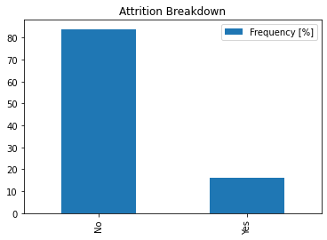

```python
plot = attrition[["Frequency [%]"]].plot(kind="bar")
plot.set_title("Attrition Breakdown")

# attrition.hist(bins=2)
# plt.title("Attrition Breakdown")
```

### Attrition vs. Age

```python
age_groupped = df.groupby("Attrition")["Attrition","Age"]
print(age_groupped.mean())
```

```
                 Age
Attrition
No         37.561233
Yes        33.607595
```

```python
df_No = df.loc[df['Attrition']=="No"]
df_Yes = df.loc[df['Attrition']=="Yes"]
```

```python
df_No_Age = df_No[df_No.columns[0:1]]
df_Yes_Age = df_Yes[df_Yes.columns[0:1]]
```

```python
age_group_yes = df_Yes_Age.groupby(by=["Age"])
age_Yes = age_group_yes["Age"].count()
```

```python
age_group_no = df_No_Age.groupby(by=["Age"])
age_No = age_group_no["Age"].count()
```

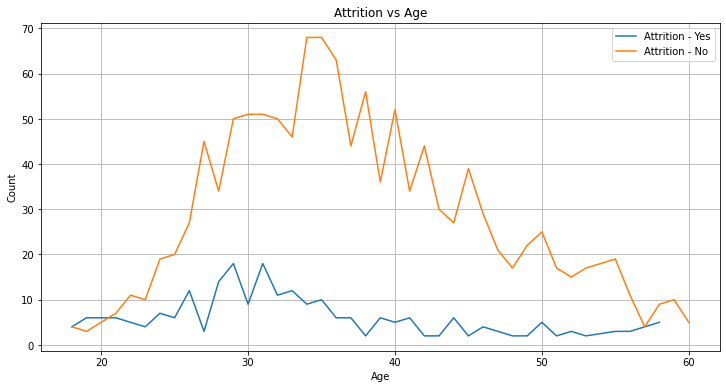

```python
plt.figure(figsize = (10,10))
aa = plt.subplot(2, 1, 1)
age_Yes.plot()
age_No.plot()
plt.grid(True)
plt.tight_layout()
aa.legend(["Attrition - Yes","Attrition - No"])
aa.set_xlabel('Age')
aa.set_ylabel('Count')
aa.set_title('Attrition vs Age')
plt.show()
```

```python
# [DS] Attrition vs. Age analysis
# Create a copy of dataframe with Attrition=Yes
df_ds_ATTR_AGE = pd.DataFrame(df,columns=["Age", "Attrition"]).copy()
# Pivot table for Age vs. Attrition
# df_ds_ATTR_AGE_cross = pd.crosstab(df_ds_ATTR_AGE["Age"], df_ds_ATTR_AGE["Attrition"])

# Create a DF with employees that left company ONLY
df_ds_ATTR_AGE_YES_only = df_ds_ATTR_AGE[df_ds_ATTR_AGE["Attrition"] == "Yes"]
# Create a DF with employees that stayed in a company ONLY
df_ds_ATTR_AGE_NO_only = df_ds_ATTR_AGE[df_ds_ATTR_AGE["Attrition"] == "No"]
# Create a DF with number of employees that left company ONLY vs. age
df_ds_ATTR_AGE_YES_only_gr = df_ds_ATTR_AGE_YES_only.groupby(by="Age").count() ["Attrition"].reset_index()
# Change the clo=umns name to include attrition "Yes"
df_ds_ATTR_AGE_YES_only_gr = df_ds_ATTR_AGE_YES_only_gr.rename(columns = {"Attrition":"Attrition_YES"})
# Create a DF with number of employees that stayed in a company ONLY vs. age
df_ds_ATTR_AGE_NO_only_gr = df_ds_ATTR_AGE_NO_only.groupby(by="Age").count() ["Attrition"].reset_index()
# Change the clo=umns name to include attrition "No"
df_ds_ATTR_AGE_NO_only_gr = df_ds_ATTR_AGE_NO_only_gr.rename(columns = {"Attrition":"Attrition_NO"})

# df_ds_ATTR_AGE_NO_only_gr
```

```python
# Merge tables with age and attrition both YES and NO
df_ds_AvsA_Y_N = pd.merge(df_ds_ATTR_AGE_YES_only_gr, df_ds_ATTR_AGE_NO_only_gr, on="Age", how="left")
# Reset index
df_ds_AvsA_Y_N.reset_index()
# Add a column with total number of employees
df_ds_AvsA_Y_N["Yes+No"] = df_ds_AvsA_Y_N["Attrition_YES"] + df_ds_AvsA_Y_N["Attrition_NO"]
# Add a column with probability of leaving a company
df_ds_AvsA_Y_N["Probability_YES"] = df_ds_AvsA_Y_N["Attrition_YES"]/df_ds_AvsA_Y_N["Yes+No"]
# Add a column with a cummulative sum of total number of employees
df_ds_AvsA_Y_N["Cum_Yes+No"] = df_ds_AvsA_Y_N["Yes+No"].cumsum()
# Add a column with a cummulative sum of total number of employees that left a company
df_ds_AvsA_Y_N["Cum_Attr_Yes"] = df_ds_AvsA_Y_N["Attrition_YES"].cumsum()
# Add a column with probability of leaving a company vs. numer of trainings on cummulativ numbers
df_ds_AvsA_Y_N["Cum_Prob_Yes"] = df_ds_AvsA_Y_N["Cum_Attr_Yes"]/df_ds_AvsA_Y_N["Cum_Yes+No"]
# print(df_ds_AvsA_Y_N)
```

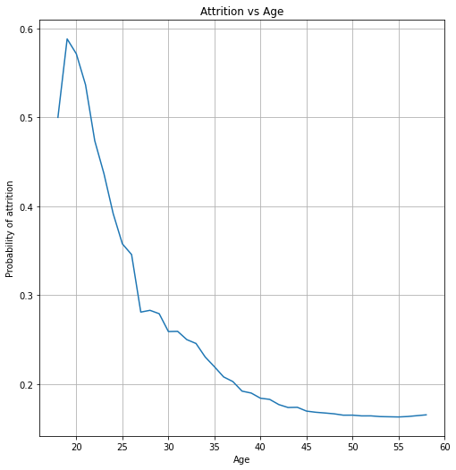

```python
plt.figure(figsize = (7,7))
AvsA_x = df_ds_AvsA_Y_N["Age"]
AvsA_y = df_ds_AvsA_Y_N["Cum_Prob_Yes"]
plt.plot(AvsA_x, AvsA_y, label="Probability")
plt.grid(True)
plt.tight_layout()
plt.xlabel('Age')
plt.ylabel('Probability of attrition')
plt.title('Attrition vs Age')
plt.show()
```

*Comment: The average age for attrition **No** is 37.56 and attrition **Yes** 33.61. The charts shows the attirition is falling with increasing age, the reason could be the fact, that people look after stability in their jobs. The chance of leaving the company is higher for peoplne in younger age.*

### Attrition vs. Monthly Income

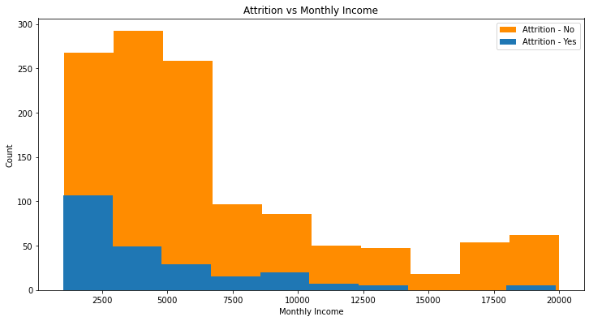

```python
plt.figure(figsize = (10,10))
am = plt.subplot(2, 1, 1)
plt.hist(df_No[["MonthlyIncome"]], color = 'darkorange')
plt.hist(df_Yes[["MonthlyIncome"]])
plt.tight_layout()
am.legend(["Attrition - No","Attrition - Yes"])
am.set_xlabel('Monthly Income')
am.set_ylabel('Count')
am.set_title('Attrition vs Monthly Income')
plt.show()
```

*Comment: Attrition in both cases tends to be high at low montly income - less than 5000 monthly. With the high salary rate - it is more likely that the employee will stay at the company.*

```python
powyzej = df_Yes[(df_Yes['MonthlyIncome'] > 17500)]
powyzej[["JobRole"]]
```

|  | JobRole |
| --- | --- |
| 45 | Research Director |
| 568 | Manager |
| 595 | Research Director |
| 749 | Manager |
| 913 | Manager |

### Attrition vs. Distance From Home

```python
df_No = df.loc[df['Attrition']=="No"]
df_Yes = df.loc[df['Attrition']=="Yes"]
```

```python
df_No_dist = df_No[df_No.columns[5:6]]
df_Yes_dist = df_Yes[df_Yes.columns[5:6]]
```

```python
dist_group_yes = df_Yes_dist.groupby(by=["DistanceFromHome"])
dist_Yes = dist_group_yes["DistanceFromHome"].count()
```

```python
dist_group_no = df_No_dist.groupby(by=["DistanceFromHome"])
dist_No = dist_group_no["DistanceFromHome"].count()
```

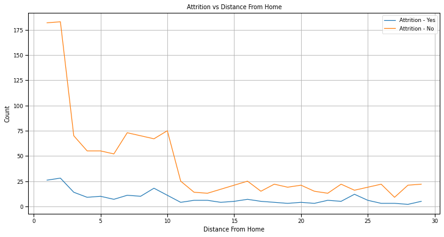

```python
plt.figure(figsize = (10,10))
dist = plt.subplot(2, 1, 1)
dist_Yes.plot()
dist_No.plot()
plt.grid(True)
plt.tight_layout()
dist.legend(["Attrition - Yes","Attrition - No"])
dist.set_xlabel('Distance From Home')
dist.set_ylabel('Count')
dist.set_title('Attrition vs Distance From Home')
plt.show()
```

*Comment: The chart shows that employees who live closer to the workplace - tend to stay at the company.*

### Attrition vs. Gender

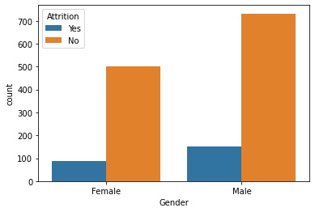

```python
sns.countplot(x = 'Gender', hue='Attrition', data=df)
```

### Attrition vs. Marital Status

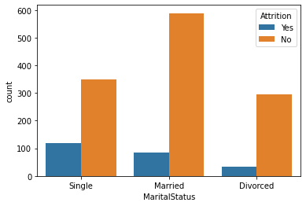

```python
sns.countplot(x = 'MaritalStatus', hue='Attrition', data=df)
```

*Comment: Attrition is higher if the employees are single.*

### Attrition vs. Environment Satisfaction

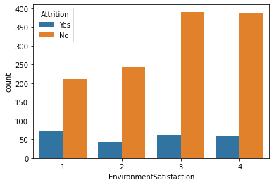

```python
sns.countplot(x = 'EnvironmentSatisfaction', hue='Attrition', data=df)
```

*Comment: For level 1 & 2 of environment satisfaction - the chances that employees will leave the company are slighly higher. The attrition rate is almost stagrant for the higher satisfaction levels.*

### Attrition vs. Numbers of Companies Worked

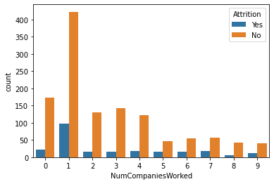

```python
sns.countplot(x = 'NumCompaniesWorked', hue='Attrition', data=df)
```

### Attrition vs. Job Satisfaction

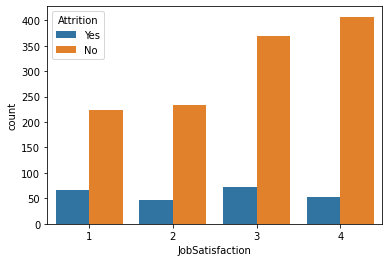

```python
sns.countplot(x = 'JobSatisfaction', hue='Attrition', data=df)
```

*Comment: People who stayed at workplace are much more satisfied with the job.*

### Attrition vs. Work Life Balance

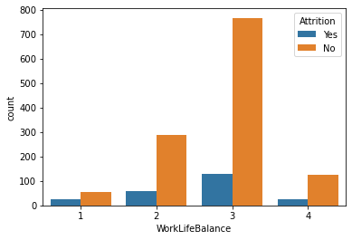

```python
sns.countplot(x = 'WorkLifeBalance', hue='Attrition', data=df)
```

### Education

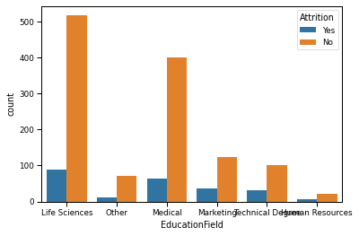

```python
sns.countplot(x = 'EducationField', hue='Attrition', data=df)
```